## **Input Domain Information**

Completed on Thu Apr 06 21:31:00 2023 (Asia/Shanghai), with the runtime of 2 seconds.

> **An interactive table** for user-input domains (n=22, being processed). The table includes three columns: 1st column `Identifier` for domain identifiers, 2nd column `Level` for domain level, and 3rd column `Description` for domain description.

| Identifier | Level | Description |
| --- | --- | --- |
| 56112 | sf | Protein kinase-like (PK-like) |
| 48726 | sf | Immunoglobulin |
| 50729 | sf | PH domain-like |
| 46785 | sf | 'Winged helix' DNA-binding domain |
| 50044 | sf | SH3-domain |
| 49265 | sf | Fibronectin type III |
| 57184 | sf | Growth factor receptor domain |
| 55550 | sf | SH2 domain |
| 47986 | sf | DEATH domain |
| 47266 | sf | 4-helical cytokines |

[output cut: 12 more lines]

## **Output: Enriched Terms**

> **An interactive table** that displays enriched ontology terms. Each enriched term (the columns `Ontology`, `Term ID` and `Term Name`) has the enrichment Z-score (`Z-score`), the enrichment significance level (`FDR`), odds ratio (`Odds ratio`) and 95% confidence intervals (`95% CI`), the number (`Num`) and list (`Members`) of member domains that overlap with your input domains. The table is sorted by FDR ascendingly.

| Ontology | Term ID | Term Name | Z-score | FDR | Odds ratio | 95% CI | Num | Members |
| --- | --- | --- | --- | --- | --- | --- | --- | --- |
| KEGG | path:hsa04658 | Th1 and Th2 cell differentiation | 7.25 | 1.3e-06 | 39.5 | [8.76, 253] | 10 | 47266, 47655, 48092, 48726, 49265, 49417, 54452, 55550, 56112, 57184 |
| KEGG | path:hsa05417 | Lipid and atherosclerosis | 6.78 | 1.3e-06 | 20.9 | [6.31, 75.5] | 12 | 47266, 47986, 49417, 50044, 50729, 52129, 52200, 54117, 55550, 56112, 57586, 57959 |
| KEGG | path:hsa05161 | Hepatitis B | 6.59 | 3.8e-06 | 23.7 | [6.24, 104] | 10 | 47266, 47655, 47986, 48092, 49417, 52129, 52200, 55550, 56112, 57959 |
| KEGG | path:hsa04659 | Th17 cell differentiation | 6.74 | 3.8e-06 | 33 | [7.17, 213] | 9 | 47266, 47655, 48092, 48726, 49265, 49417, 54452, 55550, 56112 |
| KEGG | path:hsa05169 | Epstein-Barr virus infection | 6.2 | 2.7e-05 | 27.4 | [5.79, 179] | 8 | 46785, 47266, 47986, 48726, 49417, 54452, 55550, 56112 |
| KEGG | path:hsa05162 | Measles | 5.52 | 0.00011 | 16.4 | [4.1, 73] | 8 | 47266, 47655, 47986, 48092, 49417, 52200, 55550, 56112 |
| KEGG | path:hsa04060 | Cytokine-cytokine receptor interaction | 5.63 | 0.00011 | 22.5 | [4.57, 149] | 7 | 47266, 47986, 49265, 49842, 52200, 54117, 57586 |
| KEGG | path:hsa05164 | Influenza A | 5.63 | 0.00011 | 22.5 | [4.57, 149] | 7 | 47266, 47986, 48726, 52200, 54452, 55550, 56112 |
| KEGG | path:hsa04064 | NF-kappa B signaling pathway | 5.63 | 0.00011 | 22.5 | [4.57, 149] | 7 | 47986, 49842, 52200, 54117, 55550, 56112, 57586 |
| KEGG | path:hsa05163 | Human cytomegalovirus infection | 5.27 | 0.00011 | 12.2 | [3.54, 43.7] | 9 | 47266, 47986, 49417, 50729, 54117, 54452, 55550, 56112, 57959 |

[output cut: 49 more lines]

## **Output: Dotplot**

> **A dotplot** of enriched ontology terms identified using Fisher’s exact test. An editable pdf file is also available for download.

DOWNLOAD .pdf

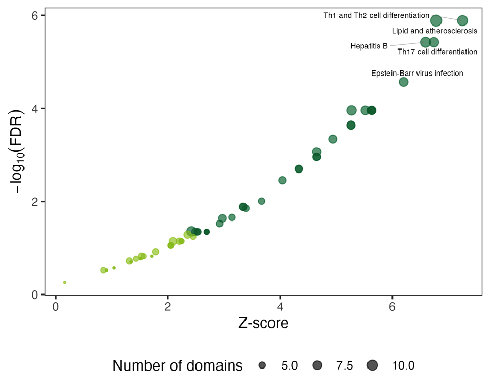

Figure 1: A dotplot of enriched ontology terms. The dots colored in dark green represent the terms with FDR < 0.05, indicating statistical significance. The top 5 significant terms (ordered by FDR ascendingly) are labelled for easier interpretation.

## **Output: Forest Plot**

> **A forest plot** of enriched ontology terms identified using Fisher’s exact test. An editable pdf file is also available for download.

DOWNLOAD .pdf

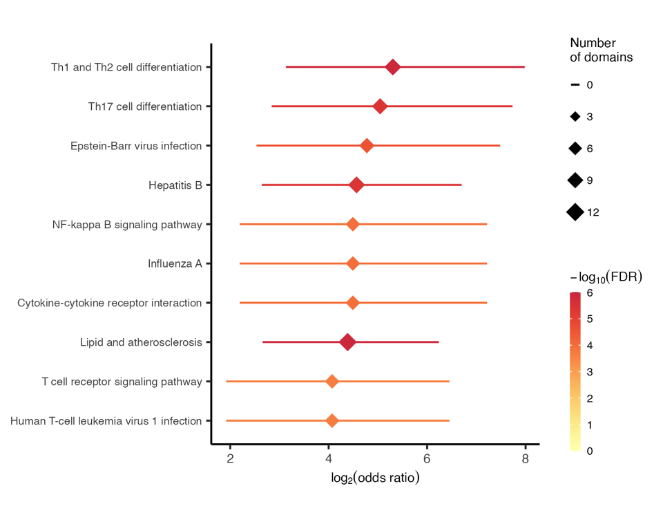

Figure 2: Forest plot for enriched ontology terms (ordered by odds ratio descendingly).